# Get started

## Clustering.

```r
# Clustering based on FPCA coordinates
dgobj <- clustering(dgobj, embedding="fpca")
```

```
#> Clustering using fPCA coordinates...
#> [DGrowthR::clustering] >> Density based clustering with DBSCAN
#> [DGrowthR::clustering] >> Using K-nearest neighbors: 23
#> [DGrowthR::clustering] >> Automatic determination of optimal eps...
#> [DGrowthR::clustering] >> Using eps value: 0.258811281594046
#> [DGrowthR::clustering] >> Updating cluster_assignment slot..
#> [DGrowthR::clustering] >> Finished
```

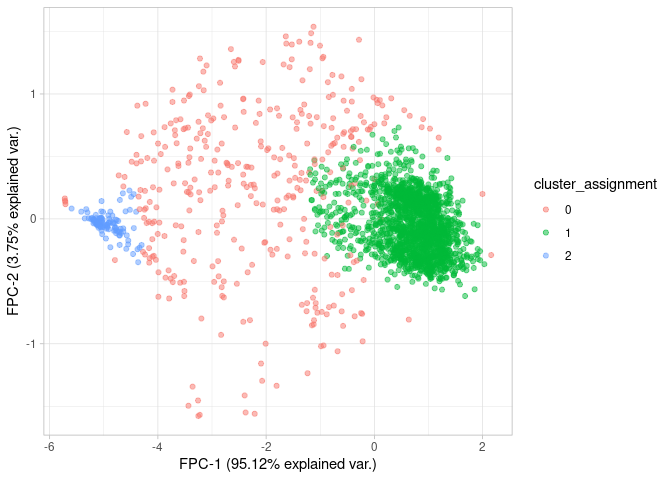

```r
# Now you can plot cluster assignment
plot_fpca(dgobj, color = "cluster_assignment")
```

Since we know that we are clustering the individual growth curves, we can plot our growth curves with updated metadata

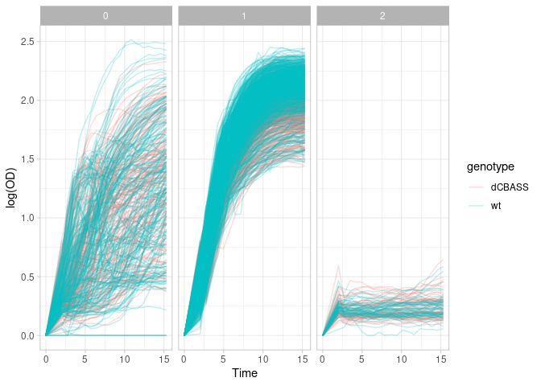

```r
plot_growth_curves(dgobj, facet="cluster_assignment", color="genotype")
```

Of course one can play around with clustering by changing the UMAP or fPCA embedding parameters, and also the clustering parameters themselves.

## Estimating growth parameters.

The growth parameters computed are:

1. **max_growth**: The maximum growth achieved.
2. **max_growth_time**: The Time at which **max_growth** was reached.
3. **AUC**: The empirical area under the curve.
4. **growth_loss**: The maximum decrease of growth after the moment of maximum growth.
5. **max_growth_rate_timepoint**: The Time at which the maximum growth rate is acheived.
6. **max_growth_rate**: The maximum specific growth rate.
7. **doubling_time**: Equal to $log(2)/\text{max_growth_rate}$.
8. **max_death_rate_timepoint**: The Time where the lowest growth rate is observed.
9. **max_death_rate**: Maximum rate of death. Properly speaking it is the lowest growth rate.
10. **lag_phase_timepoint**: The Time where lag phase ends and exponential growth begins. We find this as the maximum of the second derivative *before* **max_growth_rate_timepoint**.
11. **growth_at_lag_phase**: Amount of growth when lag phase ends.
12. **stationary_phase_timepoint**: The Time where the stationary phase starts. We find this as the minimum of the second derivative *after* **max_growth_rate_timepoint**. In a typical growth curve, this would correspond to the beginning of the stationary phase. 13 **growth_at_stationary_phase**: The amount of growth at **stationary_phase_timepoint**.

**KEEP IN MIND** the values reported are in the units that were used during modelling. Since our data was log transformed during pre-processing, all growth parameters are in units of log(OD).

To estimate growth parameters, we can use the `estimate_growth_parameters()` function.

```r
dgobj.curve_modelling <- estimate_growth_parameters(dgobj)
```

```
#> [DGrowthR::estimate_growth_parameters] >> Fitting GP models and estimating growth parameters...
#> [DGrowthR::estimate_growth_parameters] >> Modelling the curve_id field from metadata. 2304 models will be created.
#>   |                                                                              |                                                                      |   0%  |                                                                              |                                                         …
#> [DGrowthR::estimate_growth_parameters] >> Updating growth_parameters slot...
#> [DGrowthR::estimate_growth_parameters] >> Finished!
```

By default, the function models and gathers growth parameters for each individual curve and saves in the `@growth_parameters` slot. We can view it here.

```r
dgobj.curve_modelling@growth_parameters %>%
  rmarkdown::paged_table()
```

| gpfit_id | max_growth_time | max_growth | AUC | growth_loss | max_growth_rate_timepoint | max_growth_rate | doubling_time | max_death_rate_timepoint | max_death_rate | lag_phase_timepoint | growth_at_lag_phase | stationary_phase_timepoint | growth_at_stationary_phase | gpfit_converged |
| --- | --- | --- | --- | --- | --- | --- | --- | --- | --- | --- | --- | --- | --- | --- |
| dCBASS_1_OD_A1 | 12.983515 | 1.8127455 | 21.6341280 | -3.635987e-02 | 1.7002222 | 0.31904645 | 2.1725588 | 15.147434 | -3.568303e-02 | 0.0000000 | -1.533349e-02 | 5.1006667 | 1.4295075625 | yes |
| dCBASS_1_OD_A2 | 12.519818 | 2.0008332 | 23.9025692 | -1.465473e-02 | 2.1639192 | 0.39078873 | 1.7737133 | 15.147434 | -6.768954e-03 | 0.0000000 | -6.029220e-03 | 4.4824040 | 1.4948905169 | yes |
| dCBASS_1_OD_A3 | 15.302000 | 2.0460582 | 22.6239588 | 0.000000e+00 | 1.8547879 | 0.34109688 | 2.0321123 | 15.147434 | 4.607995e-03 | 0.0000000 | -2.372711e-03 | 4.3278384 | 1.3076083074 | yes |
| dCBASS_1_OD_A4 | 14.992869 | 2.0654573 | 23.4921996 | -1.261446e-03 | 2.1639192 | 0.39614455 | 1.7497330 | 15.147434 | -7.324734e-03 | 0.0000000 | -3.313823e-04 | 4.1732727 | 1.3704907772 | yes |
| dCBASS_1_OD_A5 | 15.302000 | 1.8909378 | 20.7359489 | 0.000000e+00 | 2.3184848 | 0.29493427 | 2.3501751 | 15.147434 | 3.687376e-03 | 0.0000000 | -7.218562e-03 | 4.7915354 | 1.2333094201 | yes |
| dCBASS_1_OD_A6 | 14.529172 | 2.1092378 | 24.1042329 | -1.519892e-03 | 2.0093535 | 0.34548778 | 2.0062857 | 15.147434 | -3.614039e-03 | 0.0000000 | -4.039334e-03 | 4.6369697 | 1.4327662050 | yes |
| dCBASS_1_OD_A7 | 13.447212 | 2.0478219 | 23.0183898 | -1.189622e-02 | 2.4730505 | 0.33220109 | 2.0865289 | 15.147434 | -9.323624e-03 | 0.0000000 | -4.317986e-03 | 4.9461010 | 1.4054290528 | yes |
| dCBASS_1_OD_A8 | 15.302000 | 2.0676117 | 23.5988676 | 0.000000e+00 | 2.6276162 | 0.38195347 | 1.8147425 | 12.519818 | -4.987829e-03 | 0.0000000 | -3.329378e-03 | 4.6369697 | 1.4221805946 | yes |
| dCBASS_1_OD_A9 | 15.302000 | 1.0511502 | 8.5715105 | 0.000000e+00 | 0.0000000 | 0.32937879 | 2.1044075 | 3.091313 | -3.782473e-02 | 0.0000000 | 2.793304e-03 | 0.9273939 | 0.2621285818 | yes |
| dCBASS_1_OD_A10 | 8.501111 | 1.1038241 | 12.9375776 | -3.882239e-01 | 0.0000000 | 0.39485880 | 1.7554305 | 10.819596 | -1.375074e-01 | 0.0000000 | -4.337631e-04 | 1.8547879 | 0.6309271655 | yes |

[output cut: 2294 more lines]

As you can see, the **gpfit_id** field corresponds to the **curve_id**. We actually update our low-dimensional embeddings with this data now.

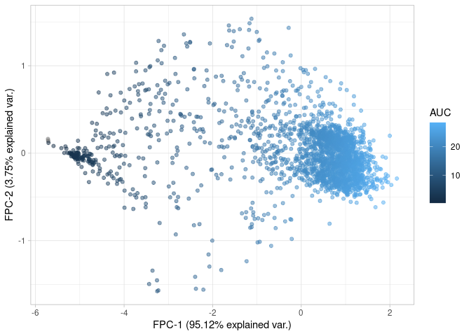

```r
# TODO: ADD THIS AS A FUNCTION?

# Gather growth parameters
growth_params <- dgobj.curve_modelling@growth_parameters %>%
  rename("curve_id" = "gpfit_id")

# Add to metadata
dgobj.curve_modelling@metadata <- dgobj.curve_modelling@metadata %>%
  left_join(growth_params, by="curve_id")

# Replot
plot_fpca(dgobj.curve_modelling, color = "AUC")
```

### Modelling groups of curves.

One additional advantage of using GP to model our curves is that we can now model several growth curves at the same time! Instead of modelling one curve at a time, we can jointly model all replicate curves that were gathered in the same experimental conditions. For example, in [Brenzinger 2024](https://www.nature.com/articles/s41564-023-01556-y) they analyse the response of a $\Delta$CBASS strain against the wildtype when confronted with different compounds. We can jointly analyse all growth curves coming from the same genotype_compound combination.

```r
dgobj.genotype_well <- estimate_growth_parameters(dgobj,
                                                  model_covariate="genotype_well", # covariate in metadata to model
                                                  save_gp_data = TRUE, # Save the GP data
                                                  n_cores=1)
```

```
#> [DGrowthR::estimate_growth_parameters] >> Fitting GP models and estimating growth parameters...
#> [DGrowthR::estimate_growth_parameters] >> Modelling the genotype_well field from metadata. 768 models will be created.
#>   |                                                                              |                                                                      |   0%  |                                                                              |                                                         …
#> [DGrowthR::estimate_growth_parameters] >> Updating growth_parameters slot...
#> [DGrowthR::estimate_growth_parameters] >> Updating gpfit_info slot...
#> [DGrowthR::estimate_growth_parameters] >> Finished!
```

Now **gpfit_id** indicates each group modelled.

```r
dgobj.genotype_well@growth_parameters %>%
  rmarkdown::paged_table()
```

| gpfit_id | max_growth_time | max_growth | AUC | growth_loss | max_growth_rate_timepoint | max_growth_rate | doubling_time | max_death_rate_timepoint | max_death_rate | lag_phase_timepoint | growth_at_lag_phase | stationary_phase_timepoint | growth_at_stationary_phase | gpfit_converged |
| --- | --- | --- | --- | --- | --- | --- | --- | --- | --- | --- | --- | --- | --- | --- |
| dCBASS_A1 | 14.065475 | 2.0395210 | 23.462332 | -1.287342e-03 | 1.7002222 | 0.31562882 | 2.196083 | 15.147434 | -2.609158e-03 | 0.0000000 | -0.0357553863 | 6.0280606 | 1.64276847 | yes |
| dCBASS_A2 | 13.910909 | 2.0740027 | 23.785403 | -2.480895e-02 | 2.4730505 | 0.34384020 | 2.015899 | 15.147434 | -3.793768e-02 | 0.0000000 | -0.0269862567 | 5.5643636 | 1.63115324 | yes |
| dCBASS_A3 | 14.683737 | 2.0190039 | 21.419697 | -5.935020e-03 | 2.6276162 | 0.31447899 | 2.204113 | 15.147434 | -1.925776e-02 | 0.0000000 | -0.0188713588 | 5.1006667 | 1.34069961 | yes |
| dCBASS_A4 | 15.147434 | 2.1008239 | 22.974805 | -8.457457e-04 | 2.4730505 | 0.38654058 | 1.793207 | 15.147434 | -5.471757e-03 | 0.0000000 | -0.0076752985 | 4.3278384 | 1.30821726 | yes |
| dCBASS_A5 | 15.147434 | 1.9264731 | 20.127520 | -5.198935e-04 | 2.9367475 | 0.28565409 | 2.426526 | 15.147434 | -3.363577e-03 | 0.0000000 | -0.0161078075 | 5.4097980 | 1.27039657 | yes |
| dCBASS_A6 | 14.374606 | 2.1427725 | 23.584512 | -1.515833e-02 | 2.6276162 | 0.32961179 | 2.102920 | 15.147434 | -2.968085e-02 | 0.0000000 | -0.0207235461 | 5.5643636 | 1.56135735 | yes |
| dCBASS_A7 | 15.302000 | 2.0679889 | 21.245035 | 0.000000e+00 | 3.8641414 | 0.28427103 | 2.438332 | 15.147434 | 3.704283e-03 | 0.0000000 | -0.0333837579 | 7.2645859 | 1.64244680 | yes |
| dCBASS_A8 | 14.220040 | 2.1198332 | 22.881464 | -1.734511e-02 | 3.5550101 | 0.33355000 | 2.078091 | 15.147434 | -3.019835e-02 | 0.0000000 | -0.0254468417 | 6.3371919 | 1.66049837 | yes |
| dCBASS_A9 | 14.992869 | 1.3875153 | 8.590479 | -4.569699e-03 | 11.1287273 | 0.22741843 | 3.047894 | 5.100667 | -3.239139e-02 | 8.1919798 | 0.3099786907 | 14.5291717 | 1.37872810 | yes |
| dCBASS_A10 | 8.501111 | 1.0000695 | 12.159740 | -1.632581e-01 | 0.1545657 | 0.24689398 | 2.807469 | 10.974162 | -5.539539e-02 | 0.0000000 | 0.0135603100 | 2.6276162 | 0.59599992 | yes |

[output cut: 758 more lines]

Additionally, we also indicated that we should save the mean GP posterior. This can now be accessed in the `@gpfit_info` field. We can also now plot this information as below.

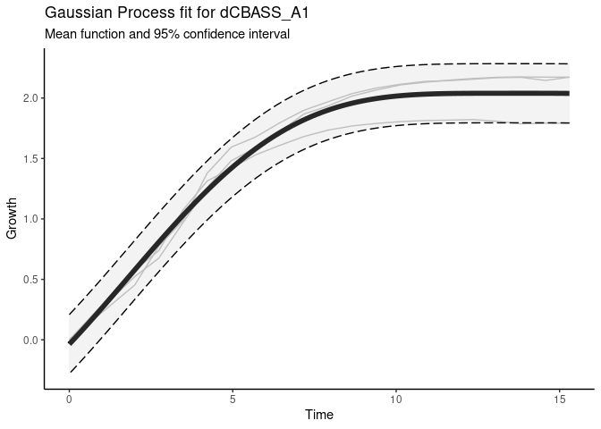

```r
plot_gp(dgobj.genotype_well, gpfit_id = "dCBASS_A1", show_input_od=TRUE)
```

Yet another great trick we can do is sample the posterior of the GP to gather an arbitrary number of synthetic growth curves. We can then gather the growth statistics from these sampled curves and get the mean and standard deviation of the growth parameters.

Keep in mind that it only makes sense to do this when the modeled covariate contains more than one growth curve per group.

```r
dgobj.genotype_well.posterior <- estimate_growth_parameters(dgobj,
                                                  model_covariate="genotype_well",

                                                  predict_n_steps = 100, # Predict a lower number of GP points to speed up

                                                  sample_posterior_gpfit=TRUE, # Sample the posterior to get mean and sd of each parameter

                                                  sample_n_curves=10,  # Number of curves to sample from posterior. 10 for speed.
                                                  save_gp_data = FALSE,
                                                  n_cores=4) # Increased number of cores
```

```r
dgobj.genotype_well.posterior@growth_parameters %>%
  rmarkdown::paged_table()
```

[output not shown]

## Differential growth.

One of the other main features of `DGrowthR` is the ability to compare growth curves gathered from different experimental conditions. This done via a likelihood ratio test. Briefly, two GP models are fit: a null model where all growth curves are modeled jointly, and an alternative model where an additional covariate is added to the design matrix indicating whether the growth curve come from the reference or treatment condition. Then the log-likelihood of these two models is compared, giving us the likelihood ratio test statistic.

In `DgrowthR` all of these steps can be run with the `growth_comparison()` function. Here a comparison is indicated to the **comparison_info** parameter as a vector consisting of (metatada_field, treatment_value, reference_value). The metadata field should be a field in the metadata, and the treatment and reference values should be found in said field. These groups of growth curves are compared to eachother as described above.

Following our example, we can compare how genotype affects the response to the same compound.

```r
object.comparison <- growth_comparison(object = dgobj,

                                       # A comparison is indicated as metadata_field, treatment, reference.
                                       comparison_info = c("genotype_well", "dCBASS_O1" ,"wt_O1"),
                                       save_gp_data = TRUE)
```

```
#> [DGrowthR::growth_comparison] >> Comparing dCBASS_O1 to wt_O1 from the genotype_well field.
#> [DGrowthR::growth_comparison] >> Finished!
```

```r
# View result of comparison
growth_comparison_result(object.comparison) %>%
  rmarkdown::paged_table()
```

| comparison | likelihood_ratio | llik.alternative_model | llik.null_model | AUC.treatment | AUC.reference | AUC.FoldChange | max_growth.treatment | max_growth.reference | max_growth.FoldChange | euclidean.distance |
| --- | --- | --- | --- | --- | --- | --- | --- | --- | --- | --- |
| genotype_well: dCBASS_O1 v.s. wt_O1 | 107.5764 | -18.80289 | -126.3793 | 14.97957 | 6.555202 | 2.285142 | 1.476493 | 0.8666306 | 1.703716 | 6.224746 |

Here we see the result of our comparison.

1. **likelihood_ratio**: Indicates the test statistic for the likelihood ratio test. It is equal to **llik.alternative_model** - **llik.null_model**.
2. **llik.alternative_model**: The log-likelihood of the GP fit with the alternative model.
3. **llik.null_model**: The log-likelihood of the GP fit with the null model.
4. **AUC.treatment**: The AUC of the alternative model fit for the treatment growth curves.
5. **AUC.reference**: The AUC of the alternative model fit for the reference growth curves.
6. **AUC.FoldChange**: Equal to $\frac{\text{AUC.treatment}}{\text{AUC.reference}}$.
7. **max_growth.treatment**: Maximum growth determined for the alternative model fit for the treatment growth curves.
8. **max_growth.reference**: Maximum growth determined for the alternative model fit for the reference growth curves.
9. **max_growth.FoldChange**: Equal to $\frac{\text{max_growth.treatment}}{\text{max_growth.reference}}$.
10. **euclidean.distance**: The euclidean distance between the model fit for the treatment and alternative curves.

We can get a better intuition by looking at a visual representation of our model. Below we see the fit of the null model, where all growth curves are modelled jointly, independent of the genotype. We can clearly see that the fit is poor.

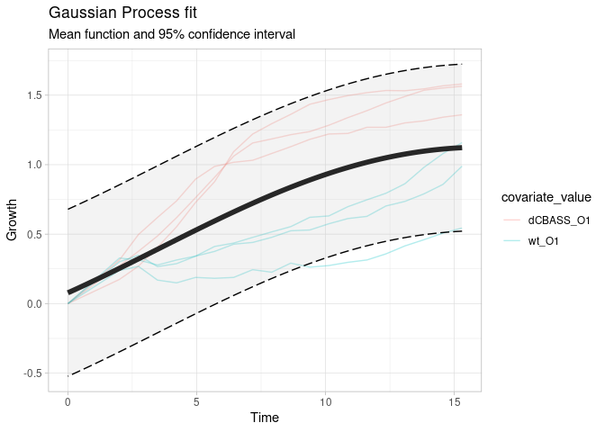

```r
model_plots <- plot_growth_comparison(object.comparison)

model_plots$null
```

The alternative model fits the original growth curves much better, indicating that these two groups might be significantly different.

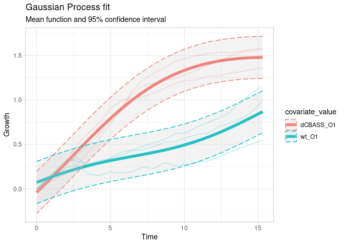

```r
model_plots$alternative
```

Of course, up until this point we only have visual evidence for this significant difference. We can get some statistical significance by performing a permutation test. In `DGrowthR` the permutation test consists of randomly shuffling the label of each growth curve and computing the log-likelihood of the alternative GP model when these curves are shuffled. Doing this several times can give us an idea of the the distribution of the likelihood ratio test statistic when curves are randomly assigned. In this case we can set the **permutation_test** parameter and indicate the number of permutations we would like to perform.

```r
object.comparison.permutation <- growth_comparison(object = dgobj,
                                       comparison_info = c("genotype_well", "dCBASS_O1" ,"wt_O1"),
                                       permutation_test=TRUE,
                                       n_permutations = 100, # Here we use 100 for speed but should probably be more
                                       n_cores = 1,
                                       save_gp_data = FALSE)
```

```
#> [DGrowthR::growth_comparison] >> Comparing dCBASS_O1 to wt_O1 from the genotype_well field.
#> [DGrowthR::perm_test] >> Perform permutation test with 100 permutations
#>   |                                                                              |                                                                      |   0%  |                                                                              |=                                                        …
#> [DGrowthR::perm_test] >> Time taken to perform permutation test: 13 second(s)
#> [DGrowthR::growth_comparison] >> Finished!
```

```r
growth_comparison_result(object.comparison.permutation)
```

```
#>                            comparison likelihood_ratio llik.alternative_model
#> 1 genotype_well: dCBASS_O1 v.s. wt_O1         107.5764              -18.80289
#>   llik.null_model AUC.treatment AUC.reference AUC.FoldChange
#> 1       -126.3793      14.97957      6.555202       2.285142
#>   max_growth.treatment max_growth.reference max_growth.FoldChange
#> 1             1.476493            0.8666306              1.703716
#>   euclidean.distance empirical_p.value
#> 1           6.224746        0.07920792
```

We can get a visual inspection of the null vs observed test statistic below

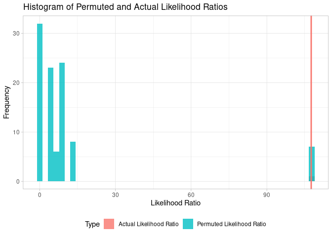

```r
plot_likelihood_ratio(object.comparison.permutation, num_bins = 50)
```

We can also plot the difference between the reference and treatment condition over time

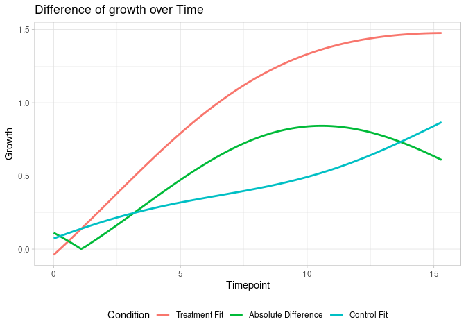

```r
plot_od_difference(object.comparison)
```

## Multiple comparisons.

Now let’s imagine that we actually want to make several comparisons in one go. For that we can use the **multiple_comparisons** function. It is actually quite similar to the function above only that now we provide a list that contains all of the comparisons we want to make

```r
contrast_list <- list(c("genotype_well", "dCBASS_O1" ,"wt_O1"),
                      c("genotype_well", "dCBASS_A1" ,"wt_A1"),
                      c("genotype_well", "dCBASS_B1" ,"wt_B1"))

# Returns a dataframe
multiple_df <- multiple_comparisons(dgobj,contrast_list, permutation_test = TRUE, n_permutations = 100)
```

```
#> [DGrowthR::multiple_comparisons] >> Computing genotype_well: dCBASS_O1 vs wt_O1 at step 1 of 3
#> [DGrowthR::growth_comparison] >> Comparing dCBASS_O1 to wt_O1 from the genotype_well field.
#> [DGrowthR::perm_test] >> Perform permutation test with 100 permutations
#>   |                                                                              |                                                                      |   0%  |                                                                              |=                                                        …
#> [DGrowthR::perm_test] >> Time taken to perform permutation test: 15 second(s)
#> [DGrowthR::growth_comparison] >> Finished!
#> [DGrowthR::multiple_comparisons] >> Computing genotype_well: dCBASS_A1 vs wt_A1 at step 2 of 3
#> [DGrowthR::growth_comparison] >> Comparing dCBASS_A1 to wt_A1 from the genotype_well field.
#> [DGrowthR::perm_test] >> Perform permutation test with 100 permutations
#>   |                                                                              |                                                                      |   0%  |                                                                              |=                                                        …
#> [DGrowthR::perm_test] >> Time taken to perform permutation test: 21 second(s)
#> [DGrowthR::growth_comparison] >> Finished!
#> [DGrowthR::multiple_comparisons] >> Computing genotype_well: dCBASS_B1 vs wt_B1 at step 3 of 3
#> [DGrowthR::growth_comparison] >> Comparing dCBASS_B1 to wt_B1 from the genotype_well field.
#> [DGrowthR::perm_test] >> Perform permutation test with 100 permutations
#>   |                                                                              |                                                                      |   0%  |                                                                              |=                                                        …
#> [DGrowthR::perm_test] >> Time taken to perform permutation test: 16 second(s)
#> [DGrowthR::growth_comparison] >> Finished!
```

Now we can view the results in one data.frame as shown below. There is also now an **pvalue.adjust** field which performs BH correction to the empirical_p.value field after all tests are done.

```r
multiple_df %>%
  rmarkdown::paged_table()
```

[output not shown]

That should be good to get you started!